# Risk Factor Analysis

## Outcome Variable

**Outcome Variable:** ever_stunted

## Predictor Variables

**Intervention Variable:** meducyrs

**Adjustment Set:**

- arm
- W_mage
- feducyrs
- W_mhtcm
- W_mwtkg
- W_mbmi
- W_gagebrth
- W_birthwt
- W_birthlen
- single
- delta_W_mage
- delta_feducyrs
- delta_W_mhtcm
- delta_W_mwtkg
- delta_W_mbmi
- delta_W_gagebrth
- delta_W_birthwt
- delta_W_birthlen
- delta_single

## Stratifying Variables

The analysis was stratified on these variable(s):

- agecat
- studyid
- country

## Data Summary

| agecat | studyid | country | meducyrs | ever_stunted | n_cell | n |
| --- | --- | --- | --- | --- | --- | --- |
| 0-24 months | CMC-V-BCS-2002 | INDIA | High | 0 | 17 | 373 |
| 0-24 months | CMC-V-BCS-2002 | INDIA | High | 1 | 141 | 373 |
| 0-24 months | CMC-V-BCS-2002 | INDIA | Low | 0 | 5 | 373 |
| 0-24 months | CMC-V-BCS-2002 | INDIA | Low | 1 | 101 | 373 |
| 0-24 months | CMC-V-BCS-2002 | INDIA | Medium | 0 | 6 | 373 |
| 0-24 months | CMC-V-BCS-2002 | INDIA | Medium | 1 | 103 | 373 |
| 0-24 months | COHORTS | GUATEMALA | High | 0 | 65 | 1341 |
| 0-24 months | COHORTS | GUATEMALA | High | 1 | 220 | 1341 |
| 0-24 months | COHORTS | GUATEMALA | Low | 0 | 132 | 1341 |
| 0-24 months | COHORTS | GUATEMALA | Low | 1 | 504 | 1341 |
| 0-24 months | COHORTS | GUATEMALA | Medium | 0 | 117 | 1341 |
| 0-24 months | COHORTS | GUATEMALA | Medium | 1 | 303 | 1341 |
| 0-24 months | COHORTS | INDIA | High | 0 | 648 | 5852 |
| 0-24 months | COHORTS | INDIA | High | 1 | 145 | 5852 |
| 0-24 months | COHORTS | INDIA | Low | 0 | 931 | 5852 |
| 0-24 months | COHORTS | INDIA | Low | 1 | 1025 | 5852 |
| 0-24 months | COHORTS | INDIA | Medium | 0 | 2039 | 5852 |
| 0-24 months | COHORTS | INDIA | Medium | 1 | 1064 | 5852 |
| 0-24 months | COHORTS | PHILIPPINES | High | 0 | 495 | 3058 |
| 0-24 months | COHORTS | PHILIPPINES | High | 1 | 678 | 3058 |
| 0-24 months | COHORTS | PHILIPPINES | Low | 0 | 177 | 3058 |
| 0-24 months | COHORTS | PHILIPPINES | Low | 1 | 726 | 3058 |
| 0-24 months | COHORTS | PHILIPPINES | Medium | 0 | 287 | 3058 |
| 0-24 months | COHORTS | PHILIPPINES | Medium | 1 | 695 | 3058 |
| 0-24 months | EE | PAKISTAN | High | 0 | 3 | 376 |
| 0-24 months | EE | PAKISTAN | High | 1 | 12 | 376 |
| 0-24 months | EE | PAKISTAN | Low | 0 | 31 | 376 |
| 0-24 months | EE | PAKISTAN | Low | 1 | 297 | 376 |
| 0-24 months | EE | PAKISTAN | Medium | 0 | 7 | 376 |
| 0-24 months | EE | PAKISTAN | Medium | 1 | 26 | 376 |

[output cut: 438 more lines]

The following strata were considered:

- agecat: 0-24 months, studyid: CMC-V-BCS-2002, country: INDIA
- agecat: 0-24 months, studyid: COHORTS, country: GUATEMALA
- agecat: 0-24 months, studyid: COHORTS, country: INDIA
- agecat: 0-24 months, studyid: COHORTS, country: PHILIPPINES
- agecat: 0-24 months, studyid: EE, country: PAKISTAN
- agecat: 0-24 months, studyid: GMS-Nepal, country: NEPAL
- agecat: 0-24 months, studyid: Guatemala BSC, country: GUATEMALA
- agecat: 0-24 months, studyid: IRC, country: INDIA
- agecat: 0-24 months, studyid: JiVitA-3, country: BANGLADESH
- agecat: 0-24 months, studyid: JiVitA-4, country: BANGLADESH
- agecat: 0-24 months, studyid: LCNI-5, country: MALAWI
- agecat: 0-24 months, studyid: MAL-ED, country: BANGLADESH
- agecat: 0-24 months, studyid: MAL-ED, country: BRAZIL
- agecat: 0-24 months, studyid: MAL-ED, country: INDIA
- agecat: 0-24 months, studyid: MAL-ED, country: NEPAL
- agecat: 0-24 months, studyid: MAL-ED, country: PERU
- agecat: 0-24 months, studyid: MAL-ED, country: SOUTH AFRICA
- agecat: 0-24 months, studyid: MAL-ED, country: TANZANIA, UNITED REPUBLIC OF
- agecat: 0-24 months, studyid: NIH-Birth, country: BANGLADESH
- agecat: 0-24 months, studyid: NIH-Crypto, country: BANGLADESH
- agecat: 0-24 months, studyid: PROBIT, country: BELARUS
- agecat: 0-24 months, studyid: PROVIDE, country: BANGLADESH
- agecat: 0-24 months, studyid: SAS-CompFeed, country: INDIA
- agecat: 0-24 months, studyid: SAS-FoodSuppl, country: INDIA
- agecat: 0-24 months, studyid: TanzaniaChild2, country: TANZANIA, UNITED REPUBLIC OF
- agecat: 0-24 months, studyid: ZVITAMBO, country: ZIMBABWE
- agecat: 0-6 months, studyid: CMC-V-BCS-2002, country: INDIA
- agecat: 0-6 months, studyid: COHORTS, country: GUATEMALA
- agecat: 0-6 months, studyid: COHORTS, country: INDIA
- agecat: 0-6 months, studyid: COHORTS, country: PHILIPPINES
- agecat: 0-6 months, studyid: EE, country: PAKISTAN
- agecat: 0-6 months, studyid: GMS-Nepal, country: NEPAL
- agecat: 0-6 months, studyid: Guatemala BSC, country: GUATEMALA
- agecat: 0-6 months, studyid: IRC, country: INDIA
- agecat: 0-6 months, studyid: JiVitA-3, country: BANGLADESH
- agecat: 0-6 months, studyid: JiVitA-4, country: BANGLADESH
- agecat: 0-6 months, studyid: LCNI-5, country: MALAWI
- agecat: 0-6 months, studyid: MAL-ED, country: BANGLADESH
- agecat: 0-6 months, studyid: MAL-ED, country: BRAZIL
- agecat: 0-6 months, studyid: MAL-ED, country: INDIA
- agecat: 0-6 months, studyid: MAL-ED, country: NEPAL
- agecat: 0-6 months, studyid: MAL-ED, country: PERU
- agecat: 0-6 months, studyid: MAL-ED, country: SOUTH AFRICA
- agecat: 0-6 months, studyid: MAL-ED, country: TANZANIA, UNITED REPUBLIC OF
- agecat: 0-6 months, studyid: NIH-Birth, country: BANGLADESH
- agecat: 0-6 months, studyid: NIH-Crypto, country: BANGLADESH
- agecat: 0-6 months, studyid: PROBIT, country: BELARUS
- agecat: 0-6 months, studyid: PROVIDE, country: BANGLADESH
- agecat: 0-6 months, studyid: SAS-CompFeed, country: INDIA
- agecat: 0-6 months, studyid: SAS-FoodSuppl, country: INDIA
- agecat: 0-6 months, studyid: TanzaniaChild2, country: TANZANIA, UNITED REPUBLIC OF
- agecat: 0-6 months, studyid: ZVITAMBO, country: ZIMBABWE
- agecat: 6-24 months, studyid: CMC-V-BCS-2002, country: INDIA
- agecat: 6-24 months, studyid: COHORTS, country: GUATEMALA
- agecat: 6-24 months, studyid: COHORTS, country: INDIA
- agecat: 6-24 months, studyid: COHORTS, country: PHILIPPINES
- agecat: 6-24 months, studyid: EE, country: PAKISTAN
- agecat: 6-24 months, studyid: GMS-Nepal, country: NEPAL
- agecat: 6-24 months, studyid: Guatemala BSC, country: GUATEMALA
- agecat: 6-24 months, studyid: IRC, country: INDIA
- agecat: 6-24 months, studyid: JiVitA-3, country: BANGLADESH
- agecat: 6-24 months, studyid: JiVitA-4, country: BANGLADESH
- agecat: 6-24 months, studyid: LCNI-5, country: MALAWI
- agecat: 6-24 months, studyid: MAL-ED, country: BANGLADESH
- agecat: 6-24 months, studyid: MAL-ED, country: BRAZIL
- agecat: 6-24 months, studyid: MAL-ED, country: INDIA
- agecat: 6-24 months, studyid: MAL-ED, country: NEPAL
- agecat: 6-24 months, studyid: MAL-ED, country: PERU
- agecat: 6-24 months, studyid: MAL-ED, country: SOUTH AFRICA
- agecat: 6-24 months, studyid: MAL-ED, country: TANZANIA, UNITED REPUBLIC OF
- agecat: 6-24 months, studyid: NIH-Birth, country: BANGLADESH
- agecat: 6-24 months, studyid: NIH-Crypto, country: BANGLADESH
- agecat: 6-24 months, studyid: PROBIT, country: BELARUS
- agecat: 6-24 months, studyid: PROVIDE, country: BANGLADESH
- agecat: 6-24 months, studyid: SAS-CompFeed, country: INDIA
- agecat: 6-24 months, studyid: SAS-FoodSuppl, country: INDIA
- agecat: 6-24 months, studyid: TanzaniaChild2, country: TANZANIA, UNITED REPUBLIC OF
- agecat: 6-24 months, studyid: ZVITAMBO, country: ZIMBABWE

### Dropped Strata

Some strata were dropped due to rare outcomes:

- agecat: 0-24 months, studyid: EE, country: PAKISTAN
- agecat: 0-24 months, studyid: MAL-ED, country: TANZANIA, UNITED REPUBLIC OF
- agecat: 0-6 months, studyid: EE, country: PAKISTAN
- agecat: 0-6 months, studyid: MAL-ED, country: TANZANIA, UNITED REPUBLIC OF
- agecat: 6-24 months, studyid: EE, country: PAKISTAN
- agecat: 6-24 months, studyid: MAL-ED, country: BRAZIL
- agecat: 6-24 months, studyid: MAL-ED, country: TANZANIA, UNITED REPUBLIC OF

## Methods Detail

We're interested in the causal parameters $E[Y_a]$ for all values of $a \in \mathcal{A}$. These parameters represent the mean outcome if, possibly contrary to fact, we intervened to set all units to have $A=a$. Under the randomization and positivity assumptions, these are identified by the statistical parameters $\psi_a=E_W[E_{Y|A,W}(Y|A=a,W)]$. In addition, we're interested in the mean of $Y$, $E[Y]$ under no intervention (the observed mean). We will estimate these parameters by using SuperLearner to fit the relevant likelihood factors -- $E_{Y|A,W}(Y|A=a,W)$ and $p(A=a|W)$, and then updating our likelihood fit using a joint TMLE.

For unadjusted analyses ($W=\{\}$), initial likelihoods were estimated using Lrnr_glm to estimate the simple $E(Y|A)$ and Lrnr_mean to estimate $p(A)$. For adjusted analyses, a small library containing Lrnr_glmnet, Lrnr_xgboost, and Lrnr_mean was used.

Having estimated these parameters, we will then use the delta method to estimate relative risks and attributable risks relative to a prespecified baseline level of $A$.

# Results Detail

## Results Plots

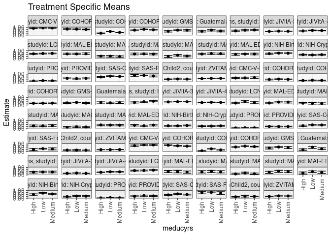

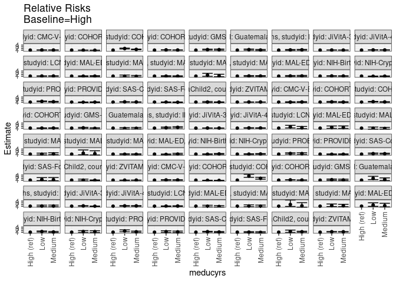

[figure not shown]

[figure not shown]

## Results Table

### Parameter: TSM

| agecat | studyid | country | intervention_level | baseline_level | estimate | ci_lower | ci_upper |
| --- | --- | --- | --- | --- | --- | --- | --- |
| 0-24 months | CMC-V-BCS-2002 | INDIA | High | NA | 0.8924051 | 0.8440236 | 0.9407866 |
| 0-24 months | CMC-V-BCS-2002 | INDIA | Low | NA | 0.9528302 | 0.9124175 | 0.9932429 |
| 0-24 months | CMC-V-BCS-2002 | INDIA | Medium | NA | 0.9449541 | 0.9020810 | 0.9878273 |
| 0-24 months | COHORTS | GUATEMALA | High | NA | 0.7887911 | 0.7354308 | 0.8421514 |
| 0-24 months | COHORTS | GUATEMALA | Low | NA | 0.7771523 | 0.7431980 | 0.8111067 |
| 0-24 months | COHORTS | GUATEMALA | Medium | NA | 0.7435514 | 0.7007371 | 0.7863658 |
| 0-24 months | COHORTS | INDIA | High | NA | 0.2450144 | 0.2155363 | 0.2744925 |
| 0-24 months | COHORTS | INDIA | Low | NA | 0.4802193 | 0.4574744 | 0.5029641 |
| 0-24 months | COHORTS | INDIA | Medium | NA | 0.3546179 | 0.3381186 | 0.3711172 |
| 0-24 months | COHORTS | PHILIPPINES | High | NA | 0.6557478 | 0.6267474 | 0.6847482 |
| 0-24 months | COHORTS | PHILIPPINES | Low | NA | 0.7578374 | 0.7242413 | 0.7914336 |
| 0-24 months | COHORTS | PHILIPPINES | Medium | NA | 0.7032219 | 0.6719837 | 0.7344601 |
| 0-24 months | GMS-Nepal | NEPAL | High | NA | 0.4934298 | 0.3952072 | 0.5916524 |
| 0-24 months | GMS-Nepal | NEPAL | Low | NA | 0.6510312 | 0.6075431 | 0.6945193 |
| 0-24 months | GMS-Nepal | NEPAL | Medium | NA | 0.6332769 | 0.5380922 | 0.7284616 |
| 0-24 months | Guatemala BSC | GUATEMALA | High | NA | 0.4946683 | 0.4048609 | 0.5844757 |
| 0-24 months | Guatemala BSC | GUATEMALA | Low | NA | 0.6461703 | 0.5414913 | 0.7508494 |
| 0-24 months | Guatemala BSC | GUATEMALA | Medium | NA | 0.5332561 | 0.4292640 | 0.6372482 |
| 0-24 months | IRC | INDIA | High | NA | 0.5611130 | 0.4782072 | 0.6440188 |
| 0-24 months | IRC | INDIA | Low | NA | 0.6398716 | 0.5638310 | 0.7159122 |
| 0-24 months | IRC | INDIA | Medium | NA | 0.6790705 | 0.6071469 | 0.7509941 |
| 0-24 months | JiVitA-3 | BANGLADESH | High | NA | 0.4888206 | 0.4746236 | 0.5030176 |
| 0-24 months | JiVitA-3 | BANGLADESH | Low | NA | 0.5187145 | 0.5060162 | 0.5314129 |
| 0-24 months | JiVitA-3 | BANGLADESH | Medium | NA | 0.5016304 | 0.4898068 | 0.5134540 |
| 0-24 months | JiVitA-4 | BANGLADESH | High | NA | 0.5482659 | 0.5185320 | 0.5779999 |
| 0-24 months | JiVitA-4 | BANGLADESH | Low | NA | 0.6173404 | 0.5823841 | 0.6522968 |
| 0-24 months | JiVitA-4 | BANGLADESH | Medium | NA | 0.6016470 | 0.5744016 | 0.6288924 |
| 0-24 months | LCNI-5 | MALAWI | High | NA | 0.6070507 | 0.5501005 | 0.6640008 |
| 0-24 months | LCNI-5 | MALAWI | Low | NA | 0.6442389 | 0.5869537 | 0.7015241 |
| 0-24 months | LCNI-5 | MALAWI | Medium | NA | 0.6580532 | 0.5985510 | 0.7175553 |

[output cut: 183 more lines]

### Parameter: E(Y)

| agecat | studyid | country | intervention_level | baseline_level | estimate | ci_lower | ci_upper |
| --- | --- | --- | --- | --- | --- | --- | --- |
| 0-24 months | CMC-V-BCS-2002 | INDIA | NA | NA | 0.9249330 | 0.8981563 | 0.9517096 |
| 0-24 months | COHORTS | GUATEMALA | NA | NA | 0.7658464 | 0.7431730 | 0.7885198 |
| 0-24 months | COHORTS | INDIA | NA | NA | 0.3817498 | 0.3693017 | 0.3941980 |
| 0-24 months | COHORTS | PHILIPPINES | NA | NA | 0.6863963 | 0.6699497 | 0.7028430 |
| 0-24 months | GMS-Nepal | NEPAL | NA | NA | 0.6388489 | 0.6031124 | 0.6745854 |
| 0-24 months | Guatemala BSC | GUATEMALA | NA | NA | 0.5531915 | 0.4950624 | 0.6113206 |
| 0-24 months | IRC | INDIA | NA | NA | 0.6414634 | 0.5949863 | 0.6879405 |
| 0-24 months | JiVitA-3 | BANGLADESH | NA | NA | 0.4953113 | 0.4874769 | 0.5031456 |
| 0-24 months | JiVitA-4 | BANGLADESH | NA | NA | 0.5822107 | 0.5661650 | 0.5982565 |
| 0-24 months | LCNI-5 | MALAWI | NA | NA | 0.6375921 | 0.6045496 | 0.6706347 |
| 0-24 months | MAL-ED | BANGLADESH | NA | NA | 0.5981308 | 0.5322895 | 0.6639722 |
| 0-24 months | MAL-ED | BRAZIL | NA | NA | 0.2715517 | 0.2141972 | 0.3289063 |
| 0-24 months | MAL-ED | INDIA | NA | NA | 0.5954545 | 0.5304515 | 0.6604576 |
| 0-24 months | MAL-ED | NEPAL | NA | NA | 0.3377778 | 0.2758420 | 0.3997135 |
| 0-24 months | MAL-ED | PERU | NA | NA | 0.6192053 | 0.5643489 | 0.6740617 |
| 0-24 months | MAL-ED | SOUTH AFRICA | NA | NA | 0.5605096 | 0.5055248 | 0.6154943 |
| 0-24 months | NIH-Birth | BANGLADESH | NA | NA | 0.6645469 | 0.6276196 | 0.7014742 |
| 0-24 months | NIH-Crypto | BANGLADESH | NA | NA | 0.4775726 | 0.4419904 | 0.5131548 |
| 0-24 months | PROBIT | BELARUS | NA | NA | 0.1274191 | 0.1115552 | 0.1432829 |
| 0-24 months | PROVIDE | BANGLADESH | NA | NA | 0.4357143 | 0.3989556 | 0.4724730 |
| 0-24 months | SAS-CompFeed | INDIA | NA | NA | 0.6914547 | 0.6510509 | 0.7318584 |
| 0-24 months | SAS-FoodSuppl | INDIA | NA | NA | 0.8277512 | 0.7915095 | 0.8639929 |
| 0-24 months | TanzaniaChild2 | TANZANIA, UNITED REPUBLIC OF | NA | NA | 0.3466052 | 0.3275063 | 0.3657041 |
| 0-24 months | ZVITAMBO | ZIMBABWE | NA | NA | 0.4173189 | 0.4091660 | 0.4254718 |
| 0-6 months | CMC-V-BCS-2002 | INDIA | NA | NA | 0.5108696 | 0.4597270 | 0.5620121 |
| 0-6 months | COHORTS | GUATEMALA | NA | NA | 0.3218924 | 0.2939898 | 0.3497950 |
| 0-6 months | COHORTS | INDIA | NA | NA | 0.1884493 | 0.1782621 | 0.1986366 |
| 0-6 months | COHORTS | PHILIPPINES | NA | NA | 0.2390451 | 0.2239262 | 0.2541640 |
| 0-6 months | GMS-Nepal | NEPAL | NA | NA | 0.3194245 | 0.2847356 | 0.3541134 |
| 0-6 months | Guatemala BSC | GUATEMALA | NA | NA | 0.3169811 | 0.2608532 | 0.3731091 |
| 0-6 months | IRC | INDIA | NA | NA | 0.4243902 | 0.3764905 | 0.4722900 |
| 0-6 months | JiVitA-3 | BANGLADESH | NA | NA | 0.4130202 | 0.4055695 | 0.4204710 |
| 0-6 months | JiVitA-4 | BANGLADESH | NA | NA | 0.3474858 | 0.3322499 | 0.3627218 |
| 0-6 months | LCNI-5 | MALAWI | NA | NA | 0.3558052 | 0.2982716 | 0.4133389 |
| 0-6 months | MAL-ED | BANGLADESH | NA | NA | 0.3411215 | 0.2774543 | 0.4047887 |
| 0-6 months | MAL-ED | BRAZIL | NA | NA | 0.2241379 | 0.1703615 | 0.2779144 |
| 0-6 months | MAL-ED | INDIA | NA | NA | 0.3272727 | 0.2651285 | 0.3894169 |
| 0-6 months | MAL-ED | NEPAL | NA | NA | 0.1777778 | 0.1277101 | 0.2278455 |
| 0-6 months | MAL-ED | PERU | NA | NA | 0.4238411 | 0.3680149 | 0.4796672 |
| 0-6 months | MAL-ED | SOUTH AFRICA | NA | NA | 0.3694268 | 0.3159570 | 0.4228965 |
| 0-6 months | NIH-Birth | BANGLADESH | NA | NA | 0.3497615 | 0.3124631 | 0.3870600 |
| 0-6 months | NIH-Crypto | BANGLADESH | NA | NA | 0.3021108 | 0.2694011 | 0.3348205 |
| 0-6 months | PROBIT | BELARUS | NA | NA | 0.0686124 | 0.0577768 | 0.0794479 |
| 0-6 months | PROVIDE | BANGLADESH | NA | NA | 0.2400000 | 0.2083392 | 0.2716608 |
| 0-6 months | SAS-CompFeed | INDIA | NA | NA | 0.4254902 | 0.3977202 | 0.4532601 |
| 0-6 months | SAS-FoodSuppl | INDIA | NA | NA | 0.3894231 | 0.3425088 | 0.4363374 |
| 0-6 months | TanzaniaChild2 | TANZANIA, UNITED REPUBLIC OF | NA | NA | 0.1948868 | 0.1789895 | 0.2107841 |
| 0-6 months | ZVITAMBO | ZIMBABWE | NA | NA | 0.2587447 | 0.2514996 | 0.2659899 |
| 6-24 months | CMC-V-BCS-2002 | INDIA | NA | NA | 0.8486486 | 0.7968646 | 0.9004327 |
| 6-24 months | COHORTS | GUATEMALA | NA | NA | 0.7666291 | 0.7387777 | 0.7944805 |
| 6-24 months | COHORTS | INDIA | NA | NA | 0.2595063 | 0.2466928 | 0.2723199 |
| 6-24 months | COHORTS | PHILIPPINES | NA | NA | 0.6449788 | 0.6246093 | 0.6653483 |
| 6-24 months | GMS-Nepal | NEPAL | NA | NA | 0.5634518 | 0.5144179 | 0.6124857 |
| 6-24 months | Guatemala BSC | GUATEMALA | NA | NA | 0.3891892 | 0.3187405 | 0.4596379 |
| 6-24 months | IRC | INDIA | NA | NA | 0.3771186 | 0.3151523 | 0.4390850 |
| 6-24 months | JiVitA-3 | BANGLADESH | NA | NA | 0.2160435 | 0.2066720 | 0.2254150 |
| 6-24 months | JiVitA-4 | BANGLADESH | NA | NA | 0.3789503 | 0.3603576 | 0.3975429 |
| 6-24 months | LCNI-5 | MALAWI | NA | NA | 0.5988701 | 0.5627418 | 0.6349983 |
| 6-24 months | MAL-ED | BANGLADESH | NA | NA | 0.4230769 | 0.3378215 | 0.5083323 |
| 6-24 months | MAL-ED | INDIA | NA | NA | 0.4214286 | 0.3393403 | 0.5035169 |
| 6-24 months | MAL-ED | NEPAL | NA | NA | 0.1978022 | 0.1397705 | 0.2558339 |
| 6-24 months | MAL-ED | PERU | NA | NA | 0.3959732 | 0.3171819 | 0.4747644 |
| 6-24 months | MAL-ED | SOUTH AFRICA | NA | NA | 0.3797468 | 0.3038314 | 0.4556622 |
| 6-24 months | NIH-Birth | BANGLADESH | NA | NA | 0.5739130 | 0.5216565 | 0.6261696 |
| 6-24 months | NIH-Crypto | BANGLADESH | NA | NA | 0.2628458 | 0.2244546 | 0.3012371 |
| 6-24 months | PROBIT | BELARUS | NA | NA | 0.0642659 | 0.0526827 | 0.0758490 |
| 6-24 months | PROVIDE | BANGLADESH | NA | NA | 0.3004386 | 0.2583143 | 0.3425629 |
| 6-24 months | SAS-CompFeed | INDIA | NA | NA | 0.5030750 | 0.4588491 | 0.5473009 |
| 6-24 months | SAS-FoodSuppl | INDIA | NA | NA | 0.7572016 | 0.7031798 | 0.8112234 |
| 6-24 months | TanzaniaChild2 | TANZANIA, UNITED REPUBLIC OF | NA | NA | 0.2266750 | 0.2061344 | 0.2472157 |
| 6-24 months | ZVITAMBO | ZIMBABWE | NA | NA | 0.2632323 | 0.2538603 | 0.2726044 |

### Parameter: RR

| agecat | studyid | country | intervention_level | baseline_level | estimate | ci_lower | ci_upper |
| --- | --- | --- | --- | --- | --- | --- | --- |
| 0-24 months | CMC-V-BCS-2002 | INDIA | High | High | 1.0000000 | 1.0000000 | 1.0000000 |
| 0-24 months | CMC-V-BCS-2002 | INDIA | Low | High | 1.0677104 | 0.9966880 | 1.1437938 |
| 0-24 months | CMC-V-BCS-2002 | INDIA | Medium | High | 1.0588848 | 0.9866120 | 1.1364517 |
| 0-24 months | COHORTS | GUATEMALA | High | High | 1.0000000 | 1.0000000 | 1.0000000 |
| 0-24 months | COHORTS | GUATEMALA | Low | High | 0.9852448 | 0.9096278 | 1.0671478 |
| 0-24 months | COHORTS | GUATEMALA | Medium | High | 0.9426468 | 0.8633228 | 1.0292592 |
| 0-24 months | COHORTS | INDIA | High | High | 1.0000000 | 1.0000000 | 1.0000000 |
| 0-24 months | COHORTS | INDIA | Low | High | 1.9599637 | 1.7266283 | 2.2248320 |
| 0-24 months | COHORTS | INDIA | Medium | High | 1.4473350 | 1.2773879 | 1.6398924 |
| 0-24 months | COHORTS | PHILIPPINES | High | High | 1.0000000 | 1.0000000 | 1.0000000 |
| 0-24 months | COHORTS | PHILIPPINES | Low | High | 1.1556843 | 1.0865436 | 1.2292247 |
| 0-24 months | COHORTS | PHILIPPINES | Medium | High | 1.0723970 | 1.0085734 | 1.1402594 |
| 0-24 months | GMS-Nepal | NEPAL | High | High | 1.0000000 | 1.0000000 | 1.0000000 |
| 0-24 months | GMS-Nepal | NEPAL | Low | High | 1.3193998 | 1.0743784 | 1.6203005 |
| 0-24 months | GMS-Nepal | NEPAL | Medium | High | 1.2834185 | 1.0043888 | 1.6399655 |
| 0-24 months | Guatemala BSC | GUATEMALA | High | High | 1.0000000 | 1.0000000 | 1.0000000 |
| 0-24 months | Guatemala BSC | GUATEMALA | Low | High | 1.3062699 | 1.0242799 | 1.6658934 |
| 0-24 months | Guatemala BSC | GUATEMALA | Medium | High | 1.0780074 | 0.8253469 | 1.4080139 |
| 0-24 months | IRC | INDIA | High | High | 1.0000000 | 1.0000000 | 1.0000000 |
| 0-24 months | IRC | INDIA | Low | High | 1.1403614 | 0.9470736 | 1.3730971 |
| 0-24 months | IRC | INDIA | Medium | High | 1.2102205 | 1.0147434 | 1.4433537 |
| 0-24 months | JiVitA-3 | BANGLADESH | High | High | 1.0000000 | 1.0000000 | 1.0000000 |
| 0-24 months | JiVitA-3 | BANGLADESH | Low | High | 1.0611552 | 1.0256186 | 1.0979231 |
| 0-24 months | JiVitA-3 | BANGLADESH | Medium | High | 1.0262055 | 0.9940343 | 1.0594180 |
| 0-24 months | JiVitA-4 | BANGLADESH | High | High | 1.0000000 | 1.0000000 | 1.0000000 |
| 0-24 months | JiVitA-4 | BANGLADESH | Low | High | 1.1259872 | 1.0462070 | 1.2118513 |
| 0-24 months | JiVitA-4 | BANGLADESH | Medium | High | 1.0973635 | 1.0256630 | 1.1740762 |
| 0-24 months | LCNI-5 | MALAWI | High | High | 1.0000000 | 1.0000000 | 1.0000000 |
| 0-24 months | LCNI-5 | MALAWI | Low | High | 1.0612605 | 0.9341119 | 1.2057162 |
| 0-24 months | LCNI-5 | MALAWI | Medium | High | 1.0840169 | 0.9527173 | 1.2334116 |

[output cut: 183 more lines]

### Parameter: PAR

| agecat | studyid | country | intervention_level | baseline_level | estimate | ci_lower | ci_upper |
| --- | --- | --- | --- | --- | --- | --- | --- |
| 0-24 months | CMC-V-BCS-2002 | INDIA | High | NA | 0.0325279 | -0.0002546 | 0.0653104 |
| 0-24 months | COHORTS | GUATEMALA | High | NA | -0.0229447 | -0.0713634 | 0.0254740 |
| 0-24 months | COHORTS | INDIA | High | NA | 0.1367355 | 0.1082942 | 0.1651767 |
| 0-24 months | COHORTS | PHILIPPINES | High | NA | 0.0306486 | 0.0070435 | 0.0542536 |
| 0-24 months | GMS-Nepal | NEPAL | High | NA | 0.1454191 | 0.0520668 | 0.2387715 |
| 0-24 months | Guatemala BSC | GUATEMALA | High | NA | 0.0585232 | -0.0097713 | 0.1268177 |
| 0-24 months | IRC | INDIA | High | NA | 0.0803504 | 0.0136342 | 0.1470665 |
| 0-24 months | JiVitA-3 | BANGLADESH | High | NA | 0.0064907 | -0.0049785 | 0.0179599 |
| 0-24 months | JiVitA-4 | BANGLADESH | High | NA | 0.0339448 | 0.0093057 | 0.0585839 |
| 0-24 months | LCNI-5 | MALAWI | High | NA | 0.0305415 | -0.0142308 | 0.0753138 |
| 0-24 months | MAL-ED | BANGLADESH | High | NA | 0.0048895 | -0.0730437 | 0.0828227 |
| 0-24 months | MAL-ED | BRAZIL | High | NA | -0.0165179 | -0.0980680 | 0.0650321 |
| 0-24 months | MAL-ED | INDIA | High | NA | 0.0041161 | -0.0957108 | 0.1039431 |
| 0-24 months | MAL-ED | NEPAL | High | NA | 0.0805664 | -0.0259688 | 0.1871017 |
| 0-24 months | MAL-ED | PERU | High | NA | 0.0376088 | -0.0453044 | 0.1205220 |
| 0-24 months | MAL-ED | SOUTH AFRICA | High | NA | 0.0359054 | -0.0451499 | 0.1169606 |
| 0-24 months | NIH-Birth | BANGLADESH | High | NA | 0.0397142 | -0.0184764 | 0.0979048 |
| 0-24 months | NIH-Crypto | BANGLADESH | High | NA | -0.0149253 | -0.0630472 | 0.0331965 |
| 0-24 months | PROBIT | BELARUS | High | NA | 0.0320150 | 0.0163189 | 0.0477112 |
| 0-24 months | PROVIDE | BANGLADESH | High | NA | -0.0089902 | -0.0602107 | 0.0422303 |
| 0-24 months | SAS-CompFeed | INDIA | High | NA | 0.0675866 | 0.0214808 | 0.1136924 |
| 0-24 months | SAS-FoodSuppl | INDIA | High | NA | -0.0015171 | -0.1110714 | 0.1080373 |
| 0-24 months | TanzaniaChild2 | TANZANIA, UNITED REPUBLIC OF | High | NA | 0.0096950 | -0.0219011 | 0.0412911 |
| 0-24 months | ZVITAMBO | ZIMBABWE | High | NA | 0.0144870 | 0.0056417 | 0.0233323 |
| 0-6 months | CMC-V-BCS-2002 | INDIA | High | NA | 0.0202078 | -0.0371857 | 0.0776013 |
| 0-6 months | COHORTS | GUATEMALA | High | NA | 0.0245936 | -0.0288280 | 0.0780152 |
| 0-6 months | COHORTS | INDIA | High | NA | 0.0278455 | 0.0080810 | 0.0476100 |
| 0-6 months | COHORTS | PHILIPPINES | High | NA | 0.0026630 | -0.0205622 | 0.0258882 |
| 0-6 months | GMS-Nepal | NEPAL | High | NA | 0.0349388 | -0.0263751 | 0.0962528 |
| 0-6 months | Guatemala BSC | GUATEMALA | High | NA | -0.0173505 | -0.0838781 | 0.0491772 |
| 0-6 months | IRC | INDIA | High | NA | 0.0843964 | 0.0225866 | 0.1462061 |
| 0-6 months | JiVitA-3 | BANGLADESH | High | NA | 0.0087836 | -0.0016164 | 0.0191836 |
| 0-6 months | JiVitA-4 | BANGLADESH | High | NA | 0.0292596 | 0.0057795 | 0.0527397 |
| 0-6 months | LCNI-5 | MALAWI | High | NA | 0.0920073 | 0.0101237 | 0.1738910 |
| 0-6 months | MAL-ED | BANGLADESH | High | NA | 0.0754475 | -0.0055484 | 0.1564435 |
| 0-6 months | MAL-ED | BRAZIL | High | NA | -0.0231601 | -0.1005455 | 0.0542253 |
| 0-6 months | MAL-ED | INDIA | High | NA | 0.0082478 | -0.0908319 | 0.1073274 |
| 0-6 months | MAL-ED | NEPAL | High | NA | 0.0457023 | -0.0374883 | 0.1288929 |
| 0-6 months | MAL-ED | PERU | High | NA | -0.0154816 | -0.0969412 | 0.0659780 |
| 0-6 months | MAL-ED | SOUTH AFRICA | High | NA | -0.0281148 | -0.1066564 | 0.0504269 |
| 0-6 months | NIH-Birth | BANGLADESH | High | NA | 0.0183460 | -0.0313763 | 0.0680683 |
| 0-6 months | NIH-Crypto | BANGLADESH | High | NA | 0.0161905 | -0.0181071 | 0.0504882 |
| 0-6 months | PROBIT | BELARUS | High | NA | 0.0177801 | 0.0023571 | 0.0332030 |
| 0-6 months | PROVIDE | BANGLADESH | High | NA | -0.0100459 | -0.0462073 | 0.0261155 |
| 0-6 months | SAS-CompFeed | INDIA | High | NA | 0.0851859 | 0.0213083 | 0.1490635 |
| 0-6 months | SAS-FoodSuppl | INDIA | High | NA | 0.1155734 | -0.0319822 | 0.2631291 |
| 0-6 months | TanzaniaChild2 | TANZANIA, UNITED REPUBLIC OF | High | NA | -0.0065983 | -0.0334094 | 0.0202128 |
| 0-6 months | ZVITAMBO | ZIMBABWE | High | NA | 0.0024478 | -0.0051001 | 0.0099956 |
| 6-24 months | CMC-V-BCS-2002 | INDIA | High | NA | 0.0585252 | -0.0020112 | 0.1190616 |
| 6-24 months | COHORTS | GUATEMALA | High | NA | -0.0748870 | -0.1226602 | -0.0271137 |
| 6-24 months | COHORTS | INDIA | High | NA | 0.1524553 | 0.1263258 | 0.1785848 |
| 6-24 months | COHORTS | PHILIPPINES | High | NA | 0.0335538 | 0.0065580 | 0.0605497 |
| 6-24 months | GMS-Nepal | NEPAL | High | NA | 0.0935392 | -0.0229372 | 0.2100155 |
| 6-24 months | Guatemala BSC | GUATEMALA | High | NA | 0.1226192 | 0.0388219 | 0.2064165 |
| 6-24 months | IRC | INDIA | High | NA | 0.0200080 | -0.0654829 | 0.1054988 |
| 6-24 months | JiVitA-3 | BANGLADESH | High | NA | -0.0000219 | -0.0188451 | 0.0188013 |
| 6-24 months | JiVitA-4 | BANGLADESH | High | NA | 0.0303617 | -0.0061218 | 0.0668451 |
| 6-24 months | LCNI-5 | MALAWI | High | NA | 0.0294686 | -0.0165248 | 0.0754620 |
| 6-24 months | MAL-ED | BANGLADESH | High | NA | -0.0285864 | -0.1365820 | 0.0794093 |
| 6-24 months | MAL-ED | INDIA | High | NA | 0.0144249 | -0.1111107 | 0.1399605 |
| 6-24 months | MAL-ED | NEPAL | High | NA | 0.0644689 | -0.0270826 | 0.1560203 |
| 6-24 months | MAL-ED | PERU | High | NA | 0.0517404 | -0.0775753 | 0.1810561 |
| 6-24 months | MAL-ED | SOUTH AFRICA | High | NA | 0.1208770 | -0.0012922 | 0.2430463 |
| 6-24 months | NIH-Birth | BANGLADESH | High | NA | 0.0874873 | 0.0130957 | 0.1618788 |
| 6-24 months | NIH-Crypto | BANGLADESH | High | NA | 0.0524124 | 0.0044100 | 0.1004147 |
| 6-24 months | PROBIT | BELARUS | High | NA | 0.0191017 | 0.0081500 | 0.0300533 |
| 6-24 months | PROVIDE | BANGLADESH | High | NA | 0.0443367 | -0.0114956 | 0.1001689 |
| 6-24 months | SAS-CompFeed | INDIA | High | NA | 0.0659280 | 0.0116985 | 0.1201575 |
| 6-24 months | SAS-FoodSuppl | INDIA | High | NA | 0.0164609 | -0.1392877 | 0.1722095 |
| 6-24 months | TanzaniaChild2 | TANZANIA, UNITED REPUBLIC OF | High | NA | 0.0412008 | 0.0077130 | 0.0746886 |
| 6-24 months | ZVITAMBO | ZIMBABWE | High | NA | 0.0232779 | 0.0125904 | 0.0339655 |

### Parameter: PAF

| agecat | studyid | country | intervention_level | baseline_level | estimate | ci_lower | ci_upper |
| --- | --- | --- | --- | --- | --- | --- | --- |
| 0-24 months | CMC-V-BCS-2002 | INDIA | High | NA | 0.0351679 | -0.0012783 | 0.0702874 |
| 0-24 months | COHORTS | GUATEMALA | High | NA | -0.0299600 | -0.0951746 | 0.0313713 |
| 0-24 months | COHORTS | INDIA | High | NA | 0.3581808 | 0.2799148 | 0.4279401 |
| 0-24 months | COHORTS | PHILIPPINES | High | NA | 0.0446514 | 0.0095989 | 0.0784633 |
| 0-24 months | GMS-Nepal | NEPAL | High | NA | 0.2276268 | 0.0668866 | 0.3606775 |
| 0-24 months | Guatemala BSC | GUATEMALA | High | NA | 0.1057919 | -0.0272011 | 0.2215661 |
| 0-24 months | IRC | INDIA | High | NA | 0.1252611 | 0.0139440 | 0.2240114 |
| 0-24 months | JiVitA-3 | BANGLADESH | High | NA | 0.0131043 | -0.0103362 | 0.0360010 |
| 0-24 months | JiVitA-4 | BANGLADESH | High | NA | 0.0583033 | 0.0149447 | 0.0997534 |
| 0-24 months | LCNI-5 | MALAWI | High | NA | 0.0479013 | -0.0251538 | 0.1157503 |
| 0-24 months | MAL-ED | BANGLADESH | High | NA | 0.0081746 | -0.1311238 | 0.1303183 |
| 0-24 months | MAL-ED | BRAZIL | High | NA | -0.0608278 | -0.4079893 | 0.2007356 |
| 0-24 months | MAL-ED | INDIA | High | NA | 0.0069126 | -0.1757620 | 0.1612056 |
| 0-24 months | MAL-ED | NEPAL | High | NA | 0.2385190 | -0.1515602 | 0.4964629 |
| 0-24 months | MAL-ED | PERU | High | NA | 0.0607372 | -0.0835221 | 0.1857899 |
| 0-24 months | MAL-ED | SOUTH AFRICA | High | NA | 0.0640584 | -0.0925886 | 0.1982466 |
| 0-24 months | NIH-Birth | BANGLADESH | High | NA | 0.0597613 | -0.0323019 | 0.1436142 |
| 0-24 months | NIH-Crypto | BANGLADESH | High | NA | -0.0312525 | -0.1371945 | 0.0648199 |
| 0-24 months | PROBIT | BELARUS | High | NA | 0.2512578 | 0.1268378 | 0.3579487 |
| 0-24 months | PROVIDE | BANGLADESH | High | NA | -0.0206334 | -0.1453101 | 0.0904713 |
| 0-24 months | SAS-CompFeed | INDIA | High | NA | 0.0977455 | 0.0298629 | 0.1608783 |
| 0-24 months | SAS-FoodSuppl | INDIA | High | NA | -0.0018328 | -0.1433253 | 0.1221493 |
| 0-24 months | TanzaniaChild2 | TANZANIA, UNITED REPUBLIC OF | High | NA | 0.0279713 | -0.0675776 | 0.1149686 |
| 0-24 months | ZVITAMBO | ZIMBABWE | High | NA | 0.0347145 | 0.0132874 | 0.0556763 |
| 0-6 months | CMC-V-BCS-2002 | INDIA | High | NA | 0.0395556 | -0.0796212 | 0.1455768 |
| 0-6 months | COHORTS | GUATEMALA | High | NA | 0.0764031 | -0.1054002 | 0.2283056 |
| 0-6 months | COHORTS | INDIA | High | NA | 0.1477613 | 0.0366990 | 0.2460188 |
| 0-6 months | COHORTS | PHILIPPINES | High | NA | 0.0111401 | -0.0909315 | 0.1036616 |
| 0-6 months | GMS-Nepal | NEPAL | High | NA | 0.1093806 | -0.1042574 | 0.2816866 |
| 0-6 months | Guatemala BSC | GUATEMALA | High | NA | -0.0547366 | -0.2869919 | 0.1356051 |
| 0-6 months | IRC | INDIA | High | NA | 0.1988650 | 0.0386618 | 0.3323710 |
| 0-6 months | JiVitA-3 | BANGLADESH | High | NA | 0.0212667 | -0.0042397 | 0.0461254 |
| 0-6 months | JiVitA-4 | BANGLADESH | High | NA | 0.0842037 | 0.0142398 | 0.1492018 |
| 0-6 months | LCNI-5 | MALAWI | High | NA | 0.2585891 | -0.0101717 | 0.4558448 |
| 0-6 months | MAL-ED | BANGLADESH | High | NA | 0.2211749 | -0.0554016 | 0.4252723 |
| 0-6 months | MAL-ED | BRAZIL | High | NA | -0.1033296 | -0.5083728 | 0.1929473 |
| 0-6 months | MAL-ED | INDIA | High | NA | 0.0252015 | -0.3297363 | 0.2853980 |
| 0-6 months | MAL-ED | NEPAL | High | NA | 0.2570755 | -0.3875966 | 0.6022354 |
| 0-6 months | MAL-ED | PERU | High | NA | -0.0365270 | -0.2474756 | 0.1387502 |
| 0-6 months | MAL-ED | SOUTH AFRICA | High | NA | -0.0761038 | -0.3112187 | 0.1168526 |
| 0-6 months | NIH-Birth | BANGLADESH | High | NA | 0.0524528 | -0.1008354 | 0.1843961 |
| 0-6 months | NIH-Crypto | BANGLADESH | High | NA | 0.0535914 | -0.0668009 | 0.1603970 |
| 0-6 months | PROBIT | BELARUS | High | NA | 0.2591381 | 0.0143809 | 0.4431151 |
| 0-6 months | PROVIDE | BANGLADESH | High | NA | -0.0418579 | -0.2042878 | 0.0986640 |
| 0-6 months | SAS-CompFeed | INDIA | High | NA | 0.2002065 | 0.0266616 | 0.3428086 |
| 0-6 months | SAS-FoodSuppl | INDIA | High | NA | 0.2967812 | -0.2072890 | 0.5903908 |
| 0-6 months | TanzaniaChild2 | TANZANIA, UNITED REPUBLIC OF | High | NA | -0.0338572 | -0.1810459 | 0.0949880 |
| 0-6 months | ZVITAMBO | ZIMBABWE | High | NA | 0.0094602 | -0.0201432 | 0.0382045 |
| 6-24 months | CMC-V-BCS-2002 | INDIA | High | NA | 0.0689628 | -0.0064293 | 0.1387073 |
| 6-24 months | COHORTS | GUATEMALA | High | NA | -0.0976834 | -0.1624318 | -0.0365416 |
| 6-24 months | COHORTS | INDIA | High | NA | 0.5874819 | 0.4779403 | 0.6740389 |
| 6-24 months | COHORTS | PHILIPPINES | High | NA | 0.0520231 | 0.0091842 | 0.0930099 |
| 6-24 months | GMS-Nepal | NEPAL | High | NA | 0.1660109 | -0.0685793 | 0.3491005 |
| 6-24 months | Guatemala BSC | GUATEMALA | High | NA | 0.3150632 | 0.0603216 | 0.5007457 |
| 6-24 months | IRC | INDIA | High | NA | 0.0530549 | -0.2031806 | 0.2547212 |
| 6-24 months | JiVitA-3 | BANGLADESH | High | NA | -0.0001015 | -0.0911360 | 0.0833379 |
| 6-24 months | JiVitA-4 | BANGLADESH | High | NA | 0.0801205 | -0.0217524 | 0.1718363 |
| 6-24 months | LCNI-5 | MALAWI | High | NA | 0.0492071 | -0.0308952 | 0.1230852 |
| 6-24 months | MAL-ED | BANGLADESH | High | NA | -0.0675677 | -0.3563494 | 0.1597291 |
| 6-24 months | MAL-ED | INDIA | High | NA | 0.0342285 | -0.3146844 | 0.2905411 |
| 6-24 months | MAL-ED | NEPAL | High | NA | 0.3259259 | -0.3262663 | 0.6574022 |
| 6-24 months | MAL-ED | PERU | High | NA | 0.1306664 | -0.2640058 | 0.4021065 |
| 6-24 months | MAL-ED | SOUTH AFRICA | High | NA | 0.3183096 | -0.0938662 | 0.5751749 |
| 6-24 months | NIH-Birth | BANGLADESH | High | NA | 0.1524400 | 0.0113583 | 0.2733889 |
| 6-24 months | NIH-Crypto | BANGLADESH | High | NA | 0.1994034 | -0.0040389 | 0.3616234 |
| 6-24 months | PROBIT | BELARUS | High | NA | 0.2972290 | 0.1089696 | 0.4457124 |
| 6-24 months | PROVIDE | BANGLADESH | High | NA | 0.1475731 | -0.0593283 | 0.3140638 |
| 6-24 months | SAS-CompFeed | INDIA | High | NA | 0.1310500 | 0.0181732 | 0.2309498 |
| 6-24 months | SAS-FoodSuppl | INDIA | High | NA | 0.0217391 | -0.2072103 | 0.2072679 |
| 6-24 months | TanzaniaChild2 | TANZANIA, UNITED REPUBLIC OF | High | NA | 0.1817616 | 0.0204768 | 0.3164899 |
| 6-24 months | ZVITAMBO | ZIMBABWE | High | NA | 0.0884311 | 0.0470159 | 0.1280466 |